# Preservation of buildings in Denmark

Nanna Elkjær-Larsen

2022-12-06

# Setting up RStudio

Firstly I will install the necessary packages.

```r
knitr::opts_chunk$set(echo = TRUE)

#install.packages("leaflet")
#install.packages("tidyverse")
#install.packages("ggplot")
```

Then i will activate the packages in my library.

```r
library(leaflet)
library(tidyverse)
library(ggplot2)
```

# Creating my dataset

The dataset which I use for this project is a list of the addresses of preservation cases in Denmark. The dataset is extracted from Kulturstyrelsens database and downloaded from their database as a pdf file. I wanted to be able to work with the data in a spreadsheet with different information separated into different columns. In order to separate the information into different columns I had to use the “text to columns” tool i excel. The “text to columns” tool allows me to divide the sentences into different columns separated by punctuation marks. In order to do this, I first had to clean the pdf from any unproductive symbols. I converted the pdf file to a word document and used the replace tool to edit out any unproductive punctuation marks e.g. “tidl.”, “beg.” as well as new lines.

After having removed any unproductive symbols, I converted the word file to an excel file. This gave me each preservation case in separate rows, but in one column. I used the “text to columns” tool and separated the text into the columns: “adress”, “name”, “description”, “preservation_date” and “remark.” I then manually had to do the final tidying. I fixed any displacements and manually added “key_id” and “council”.

Once my dataset was tidied in excel, I needed to load the coordinates from google maps. This can be done manually by looking up the adress and copying the coordinates from the URL. Seeing as I had 3861 adresses it would be more productive to have excel pull the coordinates from google maps. In order to pull the coordinates from google, I used the VBA code of the GetCoordinates, GetLatitude, and GetLongitude functions by Christos Samaras, the code is in my github repository. I inserted this code in excel under “Developer”, “Visual Basic” and made a new module. I followed the instructions of Christos Samaras and ran the code.

After having run the code, I was then able to use the function “GetLatitude” and “GetLongtitude” which pulls the coordinates from google. The coordinates were placed in the column: “lat_raw” and “lon_raw”. The number was not written with the correct decimal separator and I therefore had to divide the number by 10.000.000. This new number with the correct decimal seoperator was written in the column: “lat_tidy” and “lon_tidy.”

This is the dataset which I am now able to work with in RStudio.

# Working with data

I start of reading my dataset into RStudio:

```r
read.csv("data/Fredningsliste_tidy.csv")
adress <- read.csv("data/Fredningsliste_tidy.csv")
```

## Inspecting and correcting dataframe

After having loaded my dataframe and created an object “adress”, I will firstly inspect my dataframe to ensure it is the correct spreadsheet and correct anything which might have been mistakenly included. In order to inspect my dataframe I use the function `head()` and `tail()` as they show me the first and last part of my dataframe.

```r
head(adress)
tail(adress)
```

I am now ready to create my visualizations.

## Visualization

In order to create a map I use the leaflet package which allows me to create an interactive map. The following steps describe how the interactive map is created:

`leaflet()`: Creates an interactive map where it is possible to insert coordinates.

`setView()`: Determines the centre of the view by inserting certain coordinates, as well as the zoom. In my case i choose the coordinates for Vig on Sjælland, as this i approximately the middle of Denmark.

`addTiles()`: Adds the graphical element and layer to the map.

`addMarkers()`: Adds pins to the map. The pins are placed according to coordinates consisting of latitude and longitude. These coordinates are found in my dataframe, latitude is lat_tidy and longitude is lon_tidy. Furthermore the pins can also contain information in a popup which is also defined here showing the “name”, “preservation_date” and “description.” Finally a clustering tool is added to make the map more manageable.

`addProviderTiles()`: Customizes the map. I chose the Esri map as I find it to be clear and consistent.

`addMiniMap()`: Inserts a mini map which makes it easier to manage where in Denmark each preserved building is located, even when zooming in.

```r
map_preservation <- leaflet() %>%
  setView(11.5422344,55.8458097, zoom = 7) %>%
  addTiles() %>%
  addMarkers(lng = adress$lon_tidy,
             lat = adress$lat_tidy,
             popup = paste('<b>',adress$name,'</b>','<br>',"Adress:",adress$council,",",adress$adress,'<br>',"Preserved:",adress$preservation_date,'<br>',"Details:",'<em>',adress$description,'</em>'),
             clusterOptions = markerClusterOptions()) %>%
  addProviderTiles("Esri") %>%
  addMiniMap(tiles = "Esri"[[1]], toggleDisplay = TRUE,
             position = "topright")
map_preservation
```

[interactive chart not shown]

The final map then shows preservation cases throughout Denmark. If you click a specific building, the map shows information on the specific building, the name, the adress, when it was preserved and details on the preservation case.

# Trends of preservation in Denmark

In order to analyse trends of preservation further, I would also like to do some statistics. I want to do a chart on the preservation dates in order to examine when preservation was most frequent in time. I would also like to do statistics on which council has the most preserved buildings i Denmark.

## Preservations dates

In order the get an insight into which years most preservation cases were finalized I use the `table()` function. This function allows we to see how many times a year occurs.

```r
table(adress['preservation_date'])
```

```
## preservation_date
## 1918 1919 1920 1921 1922 1923 1924 1925 1926 1927 1930 1931 1932 1938 1939 1940 1944 1945 1946
##  589  225   13   73    1    1   38    1   10    1    2    1   46    2   65    1   26  366    4
## 1947 1948 1949 1950 1951 1952 1953 1954 1955 1959 1960 1964 1965 1968 1969 1970 1971 1972 1973
##    1    2    8  295   22    1    1   46    6  138    9  207    7    3    6   36   54   26   36
## 1974 1975 1976 1977 1978 1979 1980 1981 1982 1983 1984 1985 1986 1987 1988 1989 1990 1991 1992
##   12    8    5   67   78   85   38   41   64   76   67   56   61   81   77   68   60   42   74
## 1993 1994 1995 1996 1997 1998 1999 2000 2001 2002 2003 2004 2005 2006 2007 2008 2009 2010 2011
##   21   30   47   38   35   21   21   17   21   15   18    8   14    7   20   11   12   13    6
## 2012 2013 2014 2015 2016 2017 2018 2020 2021 2022
##    9    8    9    8    4    5    4    3    1    5
```

This gives my an idea of the answer but makes it difficult to compare the different years.

I furthermore want to inspect the data to see if I have any na values and inspect them if so. I use the `filter()` function and search specifically for na values.

```r
adress %>%
  filter(is.na(preservation_date))
```

### Visualization

I will then my a chart visualization. I use the `ggplot()` package and make a `geom_bar()` chart showing the frequency of preservation cases throughout time.

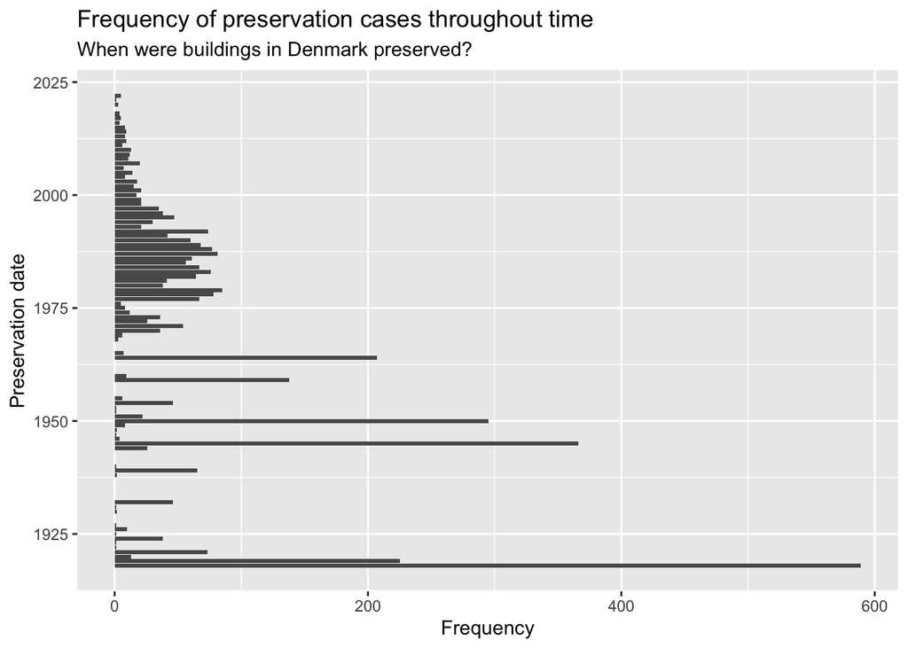

```r
adress %>%
  drop_na(preservation_date) %>%
  mutate(preservation_date = as.numeric(preservation_date)) %>%
  ggplot(aes(x=preservation_date))+
  geom_bar(stat="count")+
  theme(legend.position = "none")+
  coord_flip()+
  labs(title ="Frequency of preservation cases throughout time", subtitle = "When were buildings in Denmark preserved?", x="Preservation date", y="Frequency")
```

The chart above shows the frequency of preservation cases throughout time.

## Frequency of preservation in councils

In order to make a chart of frequency of preservation in councils I use the same method as described above. To get an overview I use the `table` function. The is as the example above hard to manage.

```r
table(adress['council'])
```

```
## council
##                                    Aabenraa Kommune           Aalborg Kommune
##                        14                        74                        38
##               Ærø Kommune             Århus Kommune           Assens Kommune
##                        43                        59                        59
##          Billund Kommune          Bornholm Kommune            Brøndby Kommune
##                         1                        57                         2
##       Brønderslev Kommune            Dragør Kommune            Egedal Kommune
##                         7                        68                         2
##           Esbjerg Kommune  Faarborg-Midtfyn Kommune              Fanø Kommune
##                       130                       100                        96
##          Favrskov Kommune              Faxe Kommune       Fredensborg Kommune
##                        10                        13                        17
##        Fredericia Kommune    Frederiksberg Kommune      Frederikshavn Kommune
##                        25                        43                        49
##     Frederikssund Kommune            Furesø Kommune         Gentofte Kommune
##                         9                         3                        51
##          Gladsaxe Kommune             Greve Kommune          Gribskov Kommune
##                         2                         3                        15
##      Guldborgsund Kommune        Haderslev Kommune            Halsnæs Kommune
##                        55                        91                        10
##        Hedensted Kommune          Helsingør Kommune           Herning Kommune
##                        11                       117                         8
##          Hillerød Kommune          Hjørring Kommune            Holbæk Kommune
##                        13                        21                        33
##        Holsterbro Kommune           Horsens Kommune          Hørsholm Kommune
##                         9                        33                        19
##         Hvidovre Kommune       Ikast-Brande Kommune            Ishøj Kommune
##                         2                         2                         2
##        Jammerbugt Kommune        Kalundborg Kommune        Kerteminde Kommune
##                        13                        40                        28
##         København Kommune              Køge Kommune           Kolding Kommune
##                       983                        54                        53
##              Læsø Kommune         Langeland Kommune             Lejre Kommune
##                        12                        36                        15
##            Lemvig Kommune           Lolland Kommune    Lyngby-Taarbæk Kommune
##                         9                        47                        42
##     Mariagerfjord Kommune        Middelfart Kommune            Morsø Kommune
##                        29                        20                         8
##           Næstved Kommune         Nordfyns Kommune           Nordjurs Kommune
```

[output cut: 8 more lines]

```
##                        69                        32                        10
##       Skanderborg Kommune             Skive Kommune          Slagelse Kommune
##                         9                        15                        48
##            Solrød Kommune        Sønderborg Kommune              Sorø Kommune
##                         1                        76                        23
##            Stevns Kommune            Struer Kommune         Svendborg Kommune
##                        19                         4                        88
##          Syddjurs Kommune            Tårnby Kommune           Thisted Kommune
##                        37                         5                        12
##            Tønder Kommune             Varde Kommune             Vejen Kommune
##                       142                        25                        15
##             Vejle Kommune   Vesthimmerlands Kommune            Viborg Kommune
##                        14                         7                        40
##      Vordingborg Kommune
##                        74
```

### Visualization

Using the `ggplot()` and `geom_bar()` functions I create a chart like the one above.

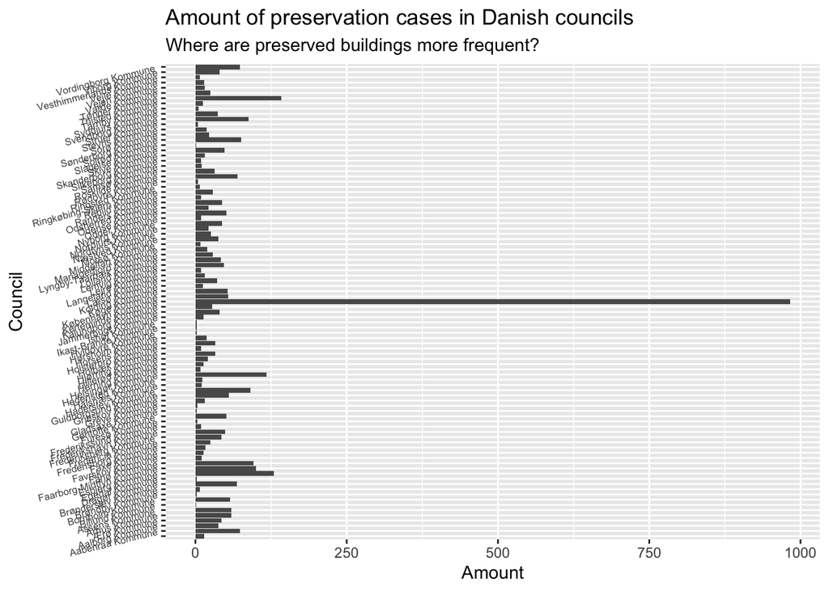

```r
ggplot(data = adress,aes(x=council))+
  geom_bar(stat="count")+
  theme(legend.position = "none")+
  coord_flip()+
  labs(title ="Amount of preservation cases in Danish councils", subtitle = "Where are preserved buildings more frequent?", x="Council", y="Amount")+
  theme(axis.text.y = element_text(angle = 14, size = 6))
```

The chart above shows frequency of preservation in each council. The chart clearly shows that København has the most preserved buildings in Denmark. In order to get at better visualization of the amount of preserved buildings in the other councils I remove “København Kommune” from the chart. I do this by using the `subset()` function.

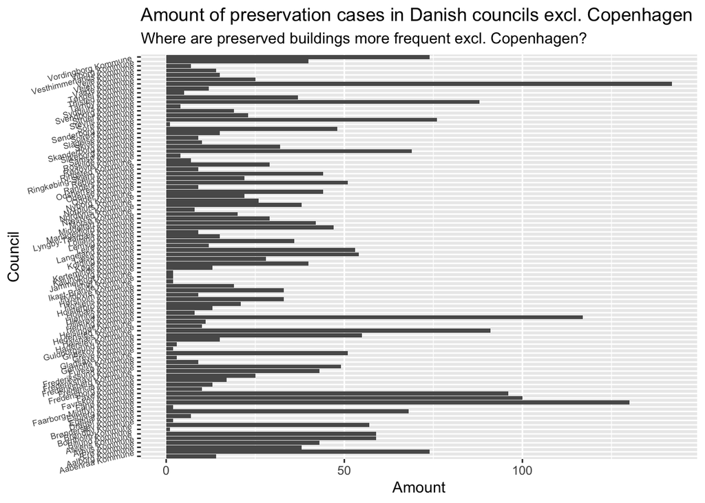

```r
ggplot(data = subset(adress, council != "København Kommune"),aes(x=council))+
  geom_bar(stat="count")+
  theme(legend.position = "none")+
  coord_flip()+
  labs(title ="Amount of preservation cases in Danish councils excl. Copenhagen", subtitle = "Where are preserved buildings more frequent excl. Copenhagen?", x="Council", y="Amount")+
  theme(axis.text.y = element_text(angle = 14, size = 6))
```

This chart shows the distinctions between the different councils better.

This chart is a little dense as it contains a lot of information. I thought of making seperate charts, one for Jylland, Fyn and København, but ultimately decided that wouldn’t be productive for the questions I seek to answer. Insted all of my visualizations can be found in better resolution in my github repository:

https://github.com/Digital-Methods-HASS/au700785_Elkjaer_Nanna